# EU Ref - GE2015

o.duke-williams@ucl.ac.uk

02/02/2021

## The 2016 EU Referendum and 2015 General Election results

This [RMarkdown](http://rmarkdown.rstudio.com/) file compares estimates and known results at constituency level for the 2016 EU Referendum.

## Sources

- [Constituency level EU Referendum results](https://commonslibrary.parliament.uk/brexit-votes-by-constituency/)
- [2015 General Election Results](https://commonslibrary.parliament.uk/research-briefings/cbp-7186/)

## Background

The 2016 EU (‘Brexit’) Referendum was conducted at local authority level: results were published for all authorities (with the overall result simply being the aggregate count across all areas). There was considerable interest in identifying results at parliamentary constituency level, and these were [modelled](https://doi.org/10.1080/17457289.2017.1287081) by Chris Hanretty. Some local authorities also published more detailed results at ward level, allowing accurate constituency data to be calculated, permitting a comparison of the Hanretty estimates and the actual results where known.

```
##     ons_id           cons_name             ch_est          result
##  Length:650         Length:650         Min.   :0.1704   Length:650
##  Class :character   Class :character   1st Qu.:0.4505   Class :character
##  Mode  :character   Mode  :character   Median :0.5364   Mode  :character
##                                        Mean   :0.5183
##                                        3rd Qu.:0.5997
##                                        Max.   :0.7565
##      leave            to_use
##  Min.   :0.0000   Min.   :0.2048
##  1st Qu.:0.0000   1st Qu.:0.4503
##  Median :0.0000   Median :0.5360
##  Mean   :0.1296   Mean   :0.5182
##  3rd Qu.:0.2206   3rd Qu.:0.5997
##  Max.   :0.7419   Max.   :0.7565
```

```
##     ons_id          ons_region_id      constituency_name  county_name
##  Length:650         Length:650         Length:650         Length:650
##  Class :character   Class :character   Class :character   Class :character
##  Mode  :character   Mode  :character   Mode  :character   Mode  :character
##
##
##
##  region_name        country_name       constituency_type  declaration_time
##  Length:650         Length:650         Length:650         Length:650
##  Class :character   Class :character   Class :character   Class :character
##  Mode  :character   Mode  :character   Mode  :character   Mode  :character
##
##
##
##     result          first_party        second_party         electorate
##  Length:650         Length:650         Length:650         Min.   : 21769
##  Class :character   Class :character   Class :character   1st Qu.: 66916
##  Mode  :character   Mode  :character   Mode  :character   Median : 71715
##                                                           Mean   : 71314
##                                                           3rd Qu.: 76406
##                                                           Max.   :108804
##   valid_votes    invalid_votes       majority          con
##  Min.   :15938   Min.   :  22.0   Min.   :   27   Min.   :    0
##  1st Qu.:42609   1st Qu.: 113.2   1st Qu.: 5611   1st Qu.: 8808
##  Median :48054   Median : 159.0   Median :10822   Median :17856
##  Mean   :47227   Mean   : 157.9   Mean   :11479   Mean   :17384
##  3rd Qu.:52214   3rd Qu.: 192.0   3rd Qu.:16705   3rd Qu.:25385
##  Max.   :70300   Max.   :1289.0   Max.   :34655   Max.   :36607
##       lab              ld             ukip           green
##  Min.   :    0   Min.   :    0   Min.   :    0   Min.   :    0
##  1st Qu.: 8448   1st Qu.: 1309   1st Qu.: 4050   1st Qu.: 1032
##  Median :14350   Median : 2120   Median : 6289   Median : 1522
##  Mean   :14380   Mean   : 3717   Mean   : 5971   Mean   : 1781
##  3rd Qu.:19279   3rd Qu.: 4198   3rd Qu.: 7864   3rd Qu.: 2256
##  Max.   :40563   Max.   :25194   Max.   :19642   Max.   :22871
##       snp              pc               dup                sf
##  Min.   :    0   Min.   :    0.0   Min.   :    0.0   Min.   :    0.0
##  1st Qu.:    0   1st Qu.:    0.0   1st Qu.:    0.0   1st Qu.:    0.0
##  Median :    0   Median :    0.0   Median :    0.0   Median :    0.0
##  Mean   : 2238   Mean   :  279.5   Mean   :  283.5   Mean   :  271.1
##  3rd Qu.:    0   3rd Qu.:    0.0   3rd Qu.:    0.0   3rd Qu.:    0.0
##  Max.   :34831   Max.   :15140.0   Max.   :19575.0   Max.   :23078.0
##       sdlp              uup             alliance           other
##  Min.   :    0.0   Min.   :    0.0   Min.   :    0.0   Min.   :    0.0
##  1st Qu.:    0.0   1st Qu.:    0.0   1st Qu.:    0.0   1st Qu.:    0.0
##  Median :    0.0   Median :    0.0   Median :    0.0   Median :  169.0
##  Mean   :  153.6   Mean   :  176.8   Mean   :   94.7   Mean   :  497.0
##  3rd Qu.:    0.0   3rd Qu.:    0.0   3rd Qu.:    0.0   3rd Qu.:  444.5
##  Max.   :18077.0   Max.   :23608.0   Max.   :16978.0   Max.   :34617.0
```

## Comparing the estimates and observed results

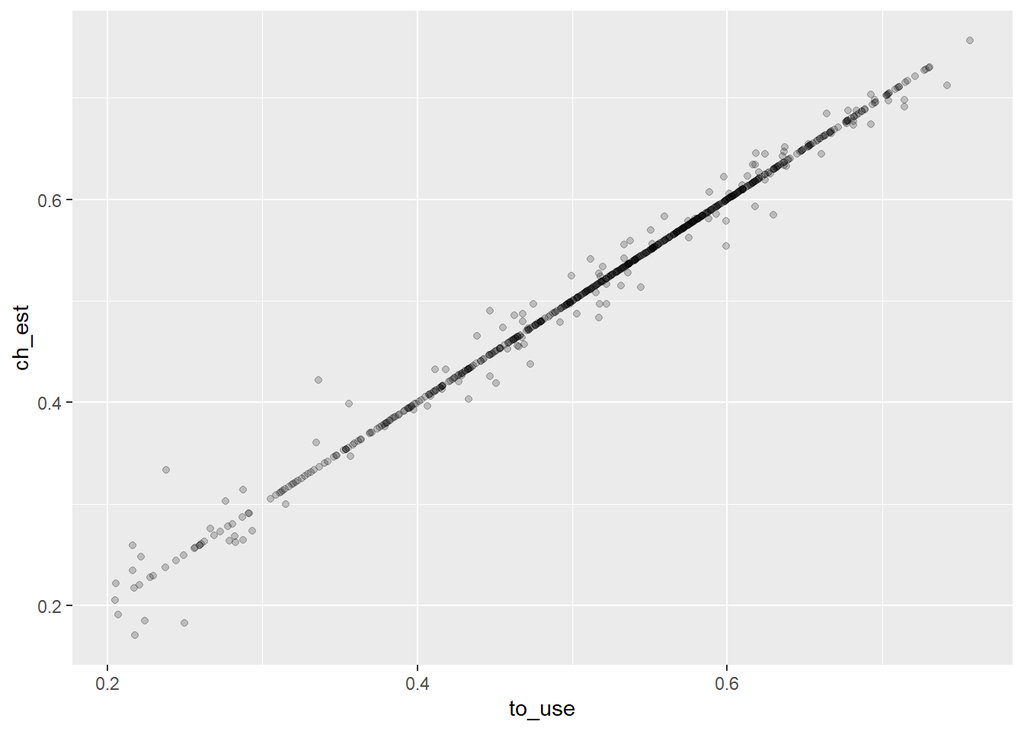

```r
plot2 <- ggplot(data=euref2016) +
  geom_point(mapping=aes(x=to_use,y=ch_est),alpha=0.2)
plot2
```

We can try filtering out those records. In order to do so, we’ll use ‘result’ in the referendum data set. This tells us whether the constituency result is available.

```r
euref_filt <- euref2016 %>% filter(result == "Yes")
```

We’ll now replot the data.

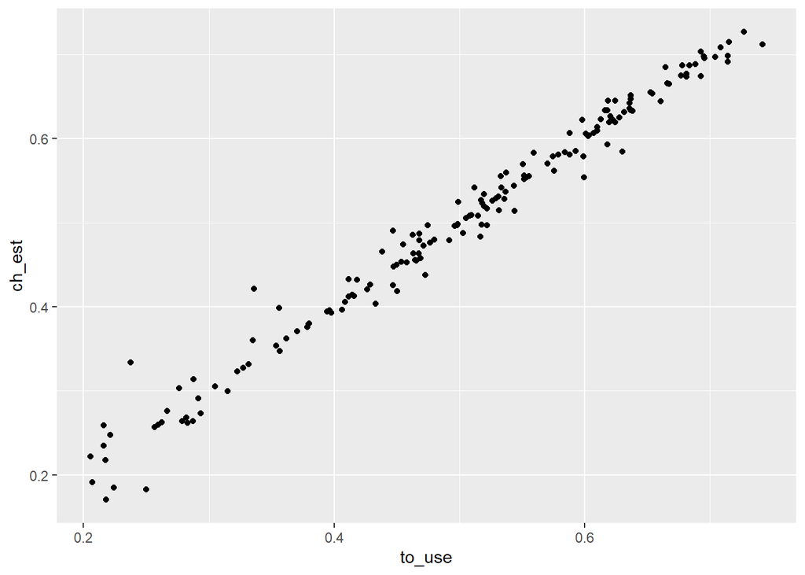

```r
plot3 <- ggplot(data=euref_filt) +
  geom_point(mapping=aes(x=to_use,y=ch_est))
plot3
```

## Party effects

There was much discussion about the relationship between party preference and referendum vote. The referendum data tells us about constituencies as places, but we also need to know about them in terms of political parties. This information is contained in our second dataset.

By merging together the referendum data set and the general election data set we can now look at this. They both have a field called ‘ons_id’ which contain consistent id codes for these areas.

###Merging data

We join the data based on the constituency, using the common field ‘ons_id’

```r
refge <- merge(euref2016,ge2015,by="ons_id")
refge[1:5,] # show a sample of the data
```

```
##      ons_id                cons_name    ch_est result.x     leave    to_use
## 1 E14000530                Aldershot 0.5809745      Yes 0.5789777 0.5789777
## 2 E14000531      Aldridge-Brownhills 0.6872275      Yes 0.6779635 0.6779635
## 3 E14000532 Altrincham and Sale West 0.3858780       No 0.0000000 0.3858780
## 4 E14000533             Amber Valley 0.6529912       No 0.0000000 0.6529912
## 5 E14000534  Arundel and South Downs 0.4970111       No 0.0000000 0.4970111
##   ons_region_id        constituency_name        county_name   region_name
## 1     E12000008                Aldershot          Hampshire    South East
## 2     E12000005      Aldridge-Brownhills      West Midlands West Midlands
## 3     E12000002 Altrincham and Sale West Greater Manchester    North West
## 4     E12000004             Amber Valley         Derbyshire East Midlands
## 5     E12000008  Arundel and South Downs        West Sussex    South East
##   country_name constituency_type declaration_time result.y first_party
## 1      England           Borough 08/05/2015 04:39 Con hold         Con
## 2      England           Borough 08/05/2015 04:55 Con hold         Con
## 3      England           Borough 08/05/2015 05:34 Con hold         Con
## 4      England            County 08/05/2015 04:31 Con hold         Con
## 5      England            County 08/05/2015 07:51 Con hold         Con
##   second_party electorate valid_votes invalid_votes majority   con   lab   ld
## 1          Lab      72430       46191           114    14901 23369  8468 4076
## 2          Lab      60215       39497           105    11723 20558  8835 1330
## 3          Lab      71511       50517           158    13290 26771 13481 4235
## 4          Lab      69510       45717           103     4205 20106 15901 1360
## 5         UKIP      77242       56477           242    26177 34331  6324 4062
##   ukip green snp pc dup sf sdlp uup alliance other
## 1 8253  2025   0  0   0  0    0   0        0     0
## 2 7751   826   0  0   0  0    0   0        0   197
## 3 4047  1983   0  0   0  0    0   0        0     0
## 4 7263  1087   0  0   0  0    0   0        0     0
## 5 8154  3606   0  0   0  0    0   0        0     0
```

### Plotting merged data

We can ask ggplot to colour points according to a value in the data. Using our merged data, we’ll use ‘first_party’ (from the election results data), which tells us which party had the highest number of votes.

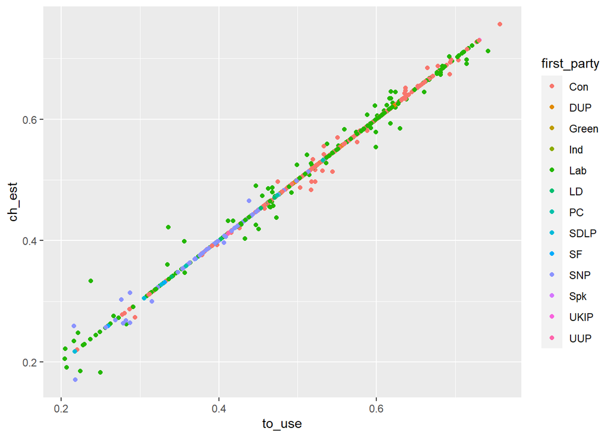

```r
plot4 <- ggplot(data=refge) +
  geom_point(mapping=aes(x=to_use,y=ch_est,colour=first_party))
plot4
```

That’s quite busy, and we also have the problem that R has used a default colour scheme. In the case of political parties, each party usually has a typical associated colour. Some times - as is the case here - several parties will have similar colours.

First though, let’s go back to using filtered data (where there is a difference between the estimate and the observed). We need to merge the data again, this time using the filtered data.

```r
refge_filt <- merge(euref_filt,ge2015,by="ons_id")
```

Now let’s plot that

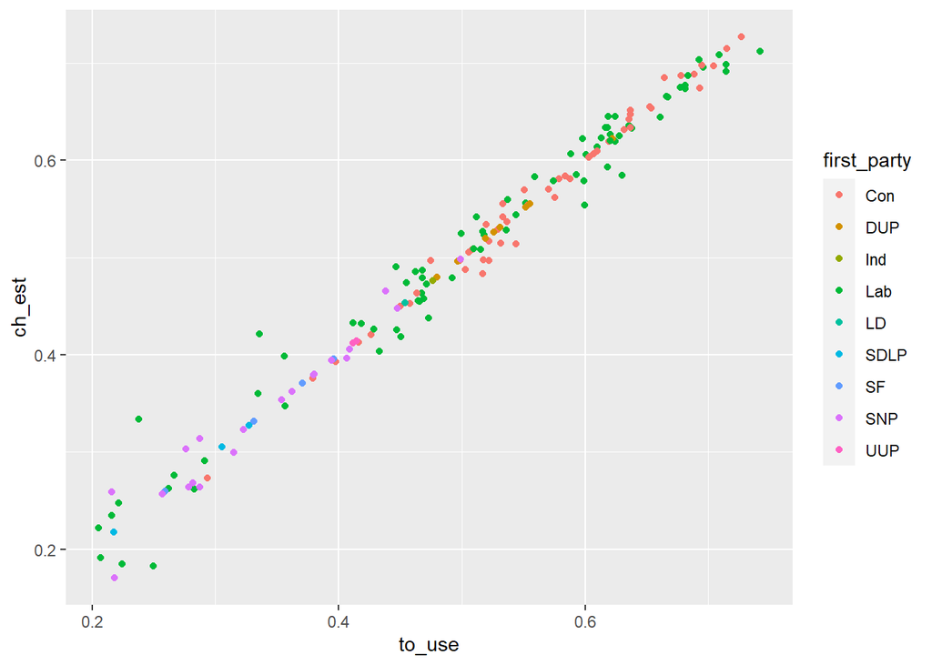

```r
plot5 <- ggplot(data=refge_filt) +
  geom_point(mapping=aes(x=to_use,y=ch_est,colour=first_party))
plot5
```

That’s easier to see, and we’ve removed quite a bit of data. We’ve also removed several parties (these ones did not have any seats in areas for which a constituency level result was available). We need to decide whether it is appropriate to drop this data.

We still want to improve the use of colour. Political parties tend to have closely associated colours. We can use some of these.

For typical colours used, see for example: [Wikipedia page on 2015 election](https://en.wikipedia.org/wiki/2015_United_Kingdom_general_election)

We still have some things to think about - there are still a lot of parties, and several of them use similar colours. Additionally, in the UK, there are different parties in England, Scotland, Wales and particularly, Northern Ireland.

However, we really just want to demonstrate what is possible here, so we will highlight a few major parties.

We have told ggplot that we want to use first_party as the variable on which to assign colours - so dots will be coloured the same if they refer to the same party; however ggplot will assign the colours.

There are a number of ways of overriding this.

In order to demonstrate one, we shall use [scale_colour_manual](https://ggplot2.tidyverse.org/reference/scale_manual.html) which allows us to manually override the colours used.

Can you add extra party colours? How many do you want to add?

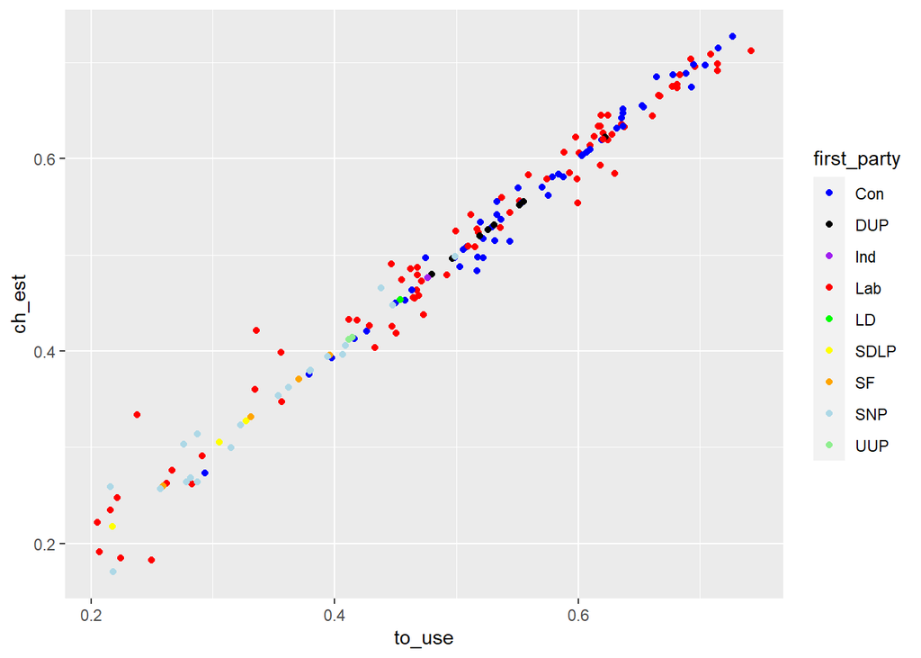

```r
cols <- c("blue","black","purple","red","green","yellow","orange","lightblue","lightgreen")
plot6 <- ggplot(data=refge_filt) +
  geom_point(mapping=aes(x=to_use,y=ch_est,colour=first_party)) +
  scale_colour_manual(values=cols)
plot6
```

## Next steps

Try adding another block of r code (the chunk name must be different to other chunks!) or adapting the plit above.

1. Add some labels (using labs)
2. Adjust the limits of the plot using xlim and ylim
3. Try adding a theme option

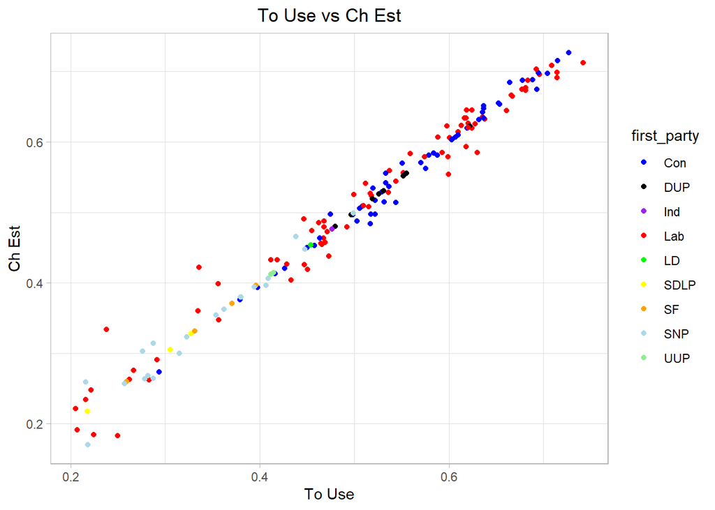

```r
cols <- c("blue","black","purple","red","green","yellow","orange","lightblue","lightgreen")
plot7 <- ggplot(data=refge_filt, xlim=c(0,1), ylim=c(0,1)) +
  geom_point(mapping=aes(x=to_use,y=ch_est,colour=first_party)) +
  scale_colour_manual(values=cols) +
  labs(x = "To Use", y = "Ch Est", title ="To Use vs Ch Est")+
  theme_light()+
theme(plot.title = element_text (hjust=0.5))
plot7
```

For examples of how to do this, you could see the R script from week 4 (which added some of these layers) or see the [ggplot cheatsheet](https://rstudio.com/wp-content/uploads/2015/03/ggplot2-cheatsheet.pdf)